# Agricultural Productivity and Deforestation: Evidence from Brazil

Szerman, Assuncao, Lipscomb, and Mobarak

APEC 8990

Paper Presentations

September 10, 2024

## Motivation

- 90% of forest loss in tropics due to agricultural expansion (Curtis et al., 2018)
- Tradeoff for development: Increase agricultural productivity leads to loss in biodiversity
- Does development through agricultural expansion neccessitate environmental degradatation?

## Research Question

> What is the effect of agricultural productivity on deforestation?

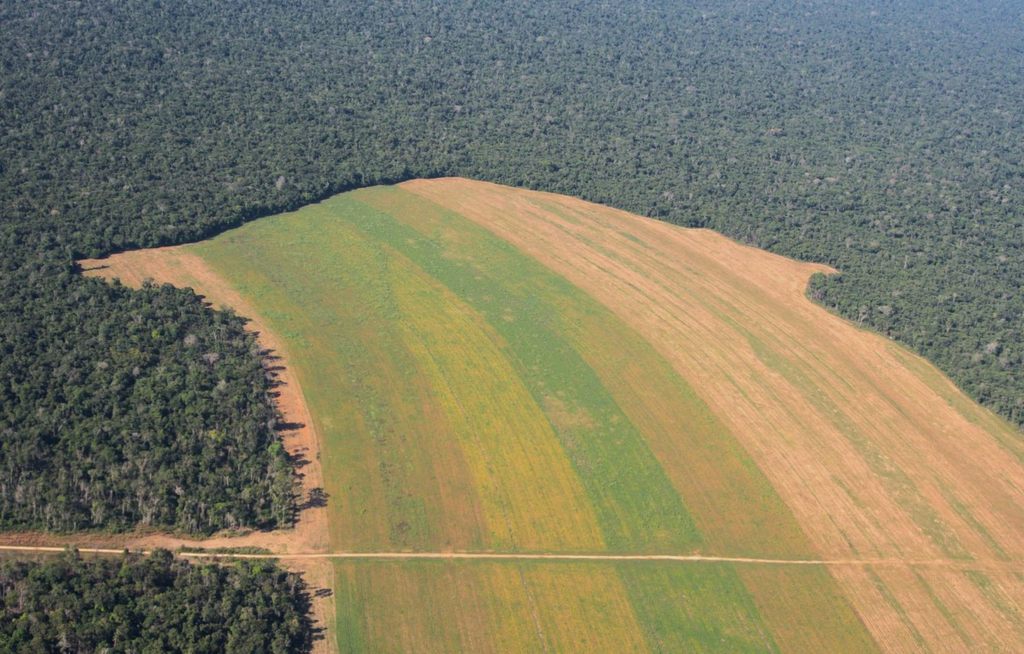

## Overview

- Intervention: rural electrification through hydropower
- Data: Brazil 1960 – 2000 of census data and satellite images
- Method: IV for counterfactual electricity grid that minimizes construction costs
- Findings:
  - Electrification increased crop yields
  - Credit-constrained farmers switched from cattle-grazing (land intensive) to cropping
  - Total agricultural land use decreased (increased efficiency)
  - Increased protection of native vegetation $\to$ reduced deforestation (ecostyem preservation)

## Data

- Brazil 1960 – 2000
- 2,172 standardized counties
1. Historical measures of electricity infrastructure by decade
   - 4% of farms have electricty in 1970. 10 fold increase in 1995
   - 32,578 spaced grids (Lipscomb et al., 2013)
2. Brazilian Censuses of Agriculture (5 waves):
   - farm expansion, land use, output, inputs
   - 3 land-types: cropland, pastures, native vegetation
3. LANDSAT Land use via satellite images
   - 30m x 30m for 30 land use types
- Issue: This is a paper about land use. There is not a single map…

## Empirical Strategy

Farmer’s problem:

Max profits using crop $H_c$ or pasture $H_g$ lands given resource $M$ and land $H$ allocations.

- Cattle grazing = land intensive
- Crop cultivation = capital intensive

$$\max_{F, H_c, H_g} \Omega K F(H_c) + F(H_g) - rK - p(H_c + H_g)$$
$$\text{ s.t. } rK + p(H_c + H_g) \le M$$
$$H_c + H_g \le H$$

## Empirical Strategy

$H_v$: Total land endowment - farmer’s agricultural demand

$$H_v = \bar{H} - \int_{-\infty}^{\bar{\theta}} (H_c^* + H_g^*) d \Gamma (\theta)$$

Predictions: Increase or decrease of native vegetation depends on:

- Intensive margin ($>0$): electrifiation impact on land demand (1st term)
- Extensive margin ($><0$): opportunity cost to farming (2nd term)

$$\frac{d H_v}{d \Omega} = - \frac{d(H_c^* + H_g^*)}{d \Omega} \Gamma (\bar{\theta}) - (H_c^* + H_g^*) \Gamma (\bar{\theta}) \frac{d \bar{\theta}}{d \Omega}$$

## Emirical Strategy

- IV: counterfactual electricity grid (Lipscomb et al. 2013)
  - Electricity expansion in Brazil is mainly hydropower
  - Costs are mainly topographical: water flow, river gradient
  - Exclusion restriction: “discontinuous jumps in receiving power early-versus-late are unlikely to be directly related to the continuous evolution of farmland expansion, pasture-to-cropland conversion, and deforestation”

## Emirical Strategy

$$E_{c,t} = \alpha_c^1 + \gamma_t^1 + \delta Z_{c,t} + \theta^1 X_{c,t} + \eta_{ct}$$
$$Y_{c,t+1} = \alpha_c^2 + \gamma_t^2 + \beta \hat{E}_{c,t} + \theta^2 X_{c,t} + \varepsilon_{ct}$$

- $\beta$: Outcome of interest for impact of electricity access
- $\delta$: Instrument using hydropower
- Time and country fixed effects.
- Clustered errors by county

## Results

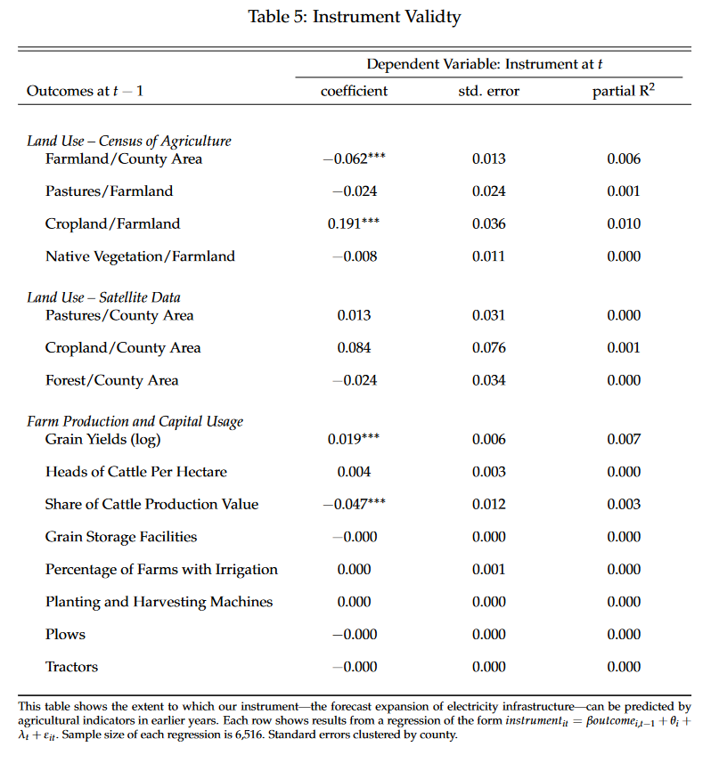

F-stat: 24.6

## Results

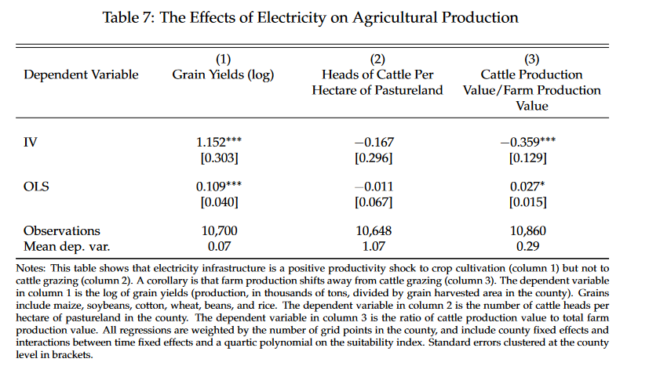

## Results

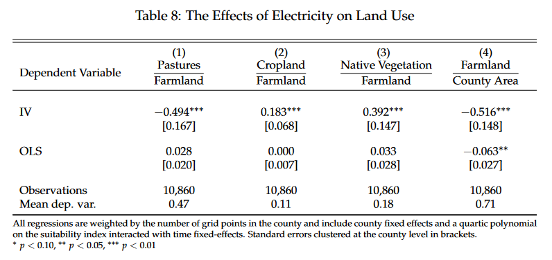

## Results

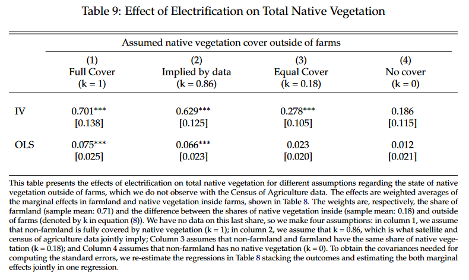

## Summary

Borlaug’s hypothesis (yield intensification) vs. Boserup’s hypothesis (expand land cultivation)

- Sharing vs. sparing debate
- Study supports Borlaug’s hypothesis

> “One potential way to reduce [environmental impacts from agriculture] is to increase food production per unit area on existing farmland, so as to minimize farmland area and to spare land for habitat conservation” (Phalan et al. 2016)